# Štatistické metódy vyhodnocovania experimentov

Tomáš Bacigál

24.2.2021

# 1 Základné štatistické metódy

## 1.1 Popisná štatistika

Ak nepoznáme rozdelenie NP, prípadne poznáme triedu rozdelenia ale nie jeho parametre, môžeme charakteristiky náhodnej premennej ( = charakteristiky rozdelenia) vypočítať z pozorovaných hodnôt (náhodného výberu).

### 1.1.1 Číselné charakteristiky

#### 1.1.1.1 Miery polohy

stredná hodnota

```r
x1 <- c(2, 4, 8, 9, 11, 11, 12)
mean(x1)  # aritmetický priemer ako odhad strednej hodnoty = sum(x1)/length(x1)
## [1] 8.142857

x2 <- c(2, 4, 8, 9, 11, 11, 120)
mean(x2)  # odľahlá hodnota priemer veľmi ovplyvní
## [1] 23.57143
```

medián

```r
median(x1)   # robustna miera polohy, t.j. necitlivá voči vybočujúcim meraniam (outliers)
## [1] 9
median(x2)
## [1] 9
```

geometrický priemer (má zmysel napr. pri priemerovaní úrokových mier za určité obdobie)

```r
gm <- function(x) prod(x)^(1/length(x))
gm(x1)   # pri zošikmených rozdeleniach býva odhad často blízky mediánu
## [1] 7.015451
exp(mean(log(x1)))  # je to vlastne iba aritmetický priemer v logaritmickej mierke
## [1] 7.015451
```

#### 1.1.1.2 Miery variability

rozptyl a štandardná odchýlka

```r
var(x1)
## [1] 14.47619
sd(x1)    # sqrt(var(x1))
## [1] 3.804759
sd(x2)
## [1] 42.65699
```

medzikvartilové rozpätie

```r
IQR(x1)
## [1] 5
IQR(x2)   # rezistentný voči outlierom
## [1] 5
quantile(x1, probs=0.25)   # dolný kvartil
## 25%
##   6
```

```r
mad(x1)
## [1] 2.9652
median(abs(x1-median(x1))) * 1.4826
## [1] 2.9652
# konštanta zabezpečuje konzistentnosť so štandardnou odchýlkou a normálnym rozdelenim
mad(x2) # MAD je robustná miera variability
## [1] 2.9652
```

#### 1.1.1.3 Miery šikmosti (asymetrie)

klasická miera šikmosti

```r
( n <- length(x1) )
## [1] 7
sum((x1-mean(x1))^3) / sd(x1)^3 * n/((n-1)*(n-2))
## [1] -0.8398416

sikmost <- function(x) {
  sum((x-mean(x))^3) / sd(x)^3 *
    length(x)/((length(x)-1)*(length(x)-2))
}
sikmost(x1)
## [1] -0.8398416
```

### 1.1.2 Grafické charakteristiky rozdelenia jedinej veličiny

#### 1.1.2.1 Diskrétne náhodné premenné

```r
set.seed(10)
x3 <- rbinom(100, size=20, prob=0.8)
```

K vytvoreniu predstavy o rozdelení pravdepodobnosti diskrétnych premenných si v prvom “nástrele” často pomáhame najmä **tabuľkami početnosti**,

```r
table(x3)
## x3
## 13 14 15 16 17 18 19
##  3  8 14 29 26 13  7
```

no v rýchlosti odovzdania (komplexnej) informácie číselné charakteristiky málokedy môžu konkurovať vhodnej vizualizácii. Ukážeme si tie najbežnejšie grafické reprezentácie rozdelenia z náhodného výberu.

Obyčajný graf je málo informatívny, pretože poradie prvku zobrazené na osi x nedáva cennú informáciu.

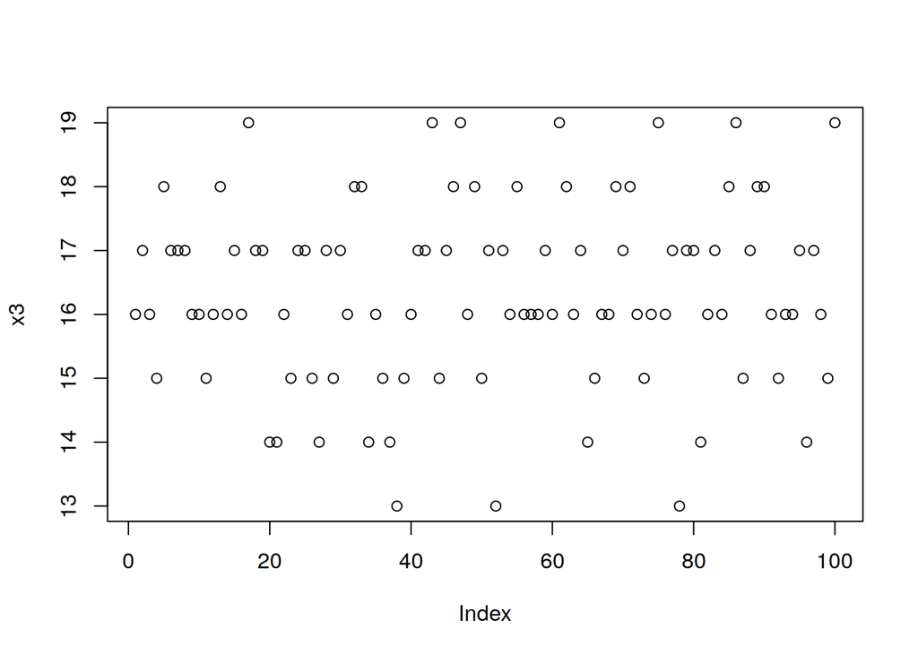

```r
plot(x3)
```

Najužitočnejší je **stĺpcový graf** (*bar chart*), ktorý vizualizuje frekvenčnú tabuľku.

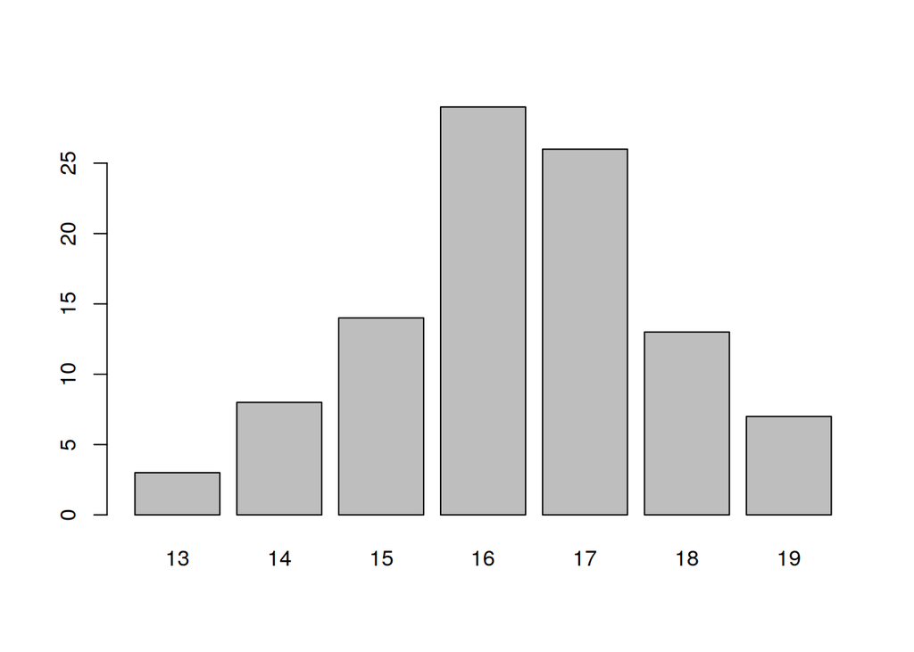

```r
barplot(table(x3))
```

Ak je unikátnych hodnôt premennej viac, než sa zmestí na os x vedľa seba, resp. ak ich potrebujeme zoskupiť do intervalov (v prípade kvantitatívnej premennej), potrebujeme **histogram**. Môže sa doplniť o **kobercový graf** (*rug*), ale ten je užitočnejší skôr v prípade spojitej náh.premennej. Tu hodnoty musíme rozochvieť (*jitter*), aby neboli v zákryte a bolo jednotlivé hodnoty vidieť.

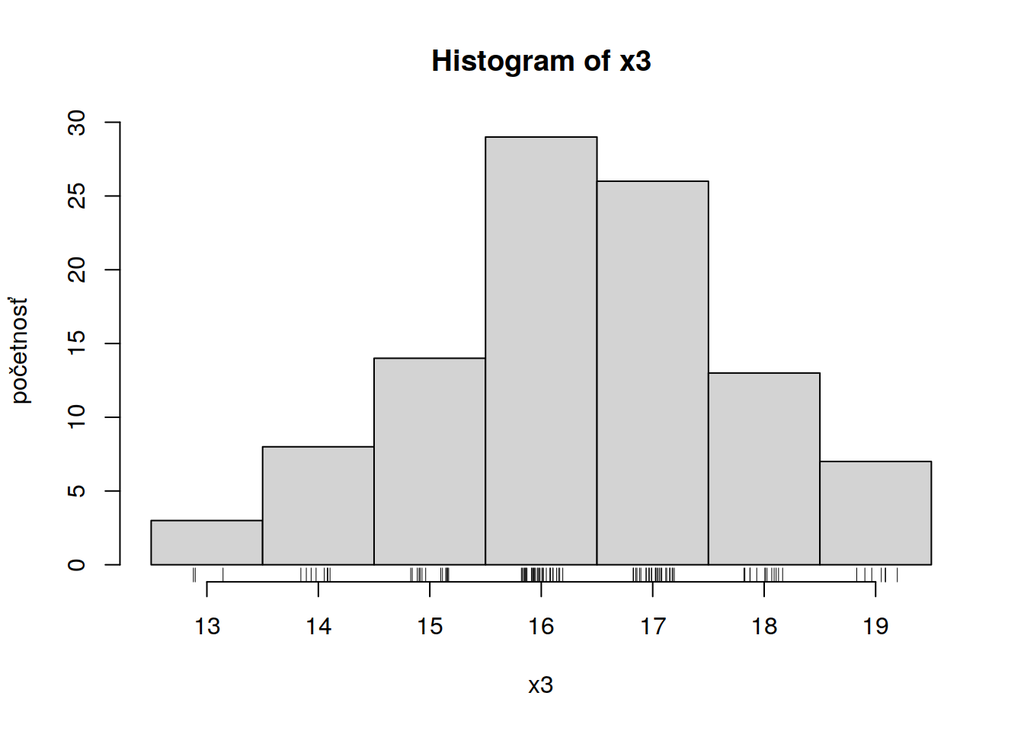

```r
table(cut(x3, breaks=12.5:19.5))  # intervaly sú zadané deliacimi bodmi
##
## (12.5,13.5] (13.5,14.5] (14.5,15.5] (15.5,16.5] (16.5,17.5] (17.5,18.5]
##           3           8          14          29          26          13
## (18.5,19.5]
##           7
hist(x3, breaks=12.5:19.5, ylab="početnosť")
rug(jitter(x3))
```

Alternatívou ku stĺpcovému grafu sú Clevelandov bodový graf (dot chart) a ak treba zobraziť iba percentuálne zastúpenie, tak koláčový graf (pie chart).

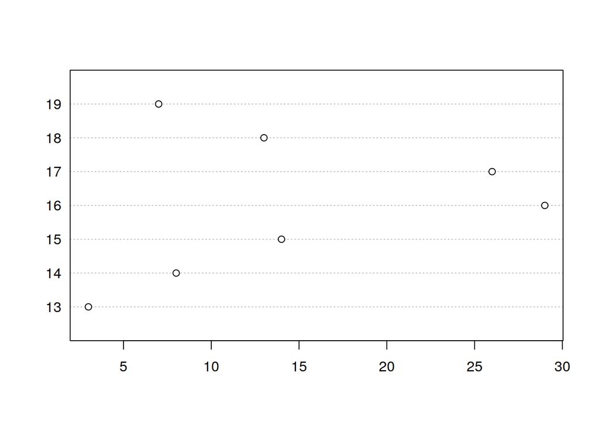

```r
dotchart(table(x3))
## Warning in dotchart(table(x3)): 'x' is neither a vector nor a matrix: using
## as.numeric(x)
```

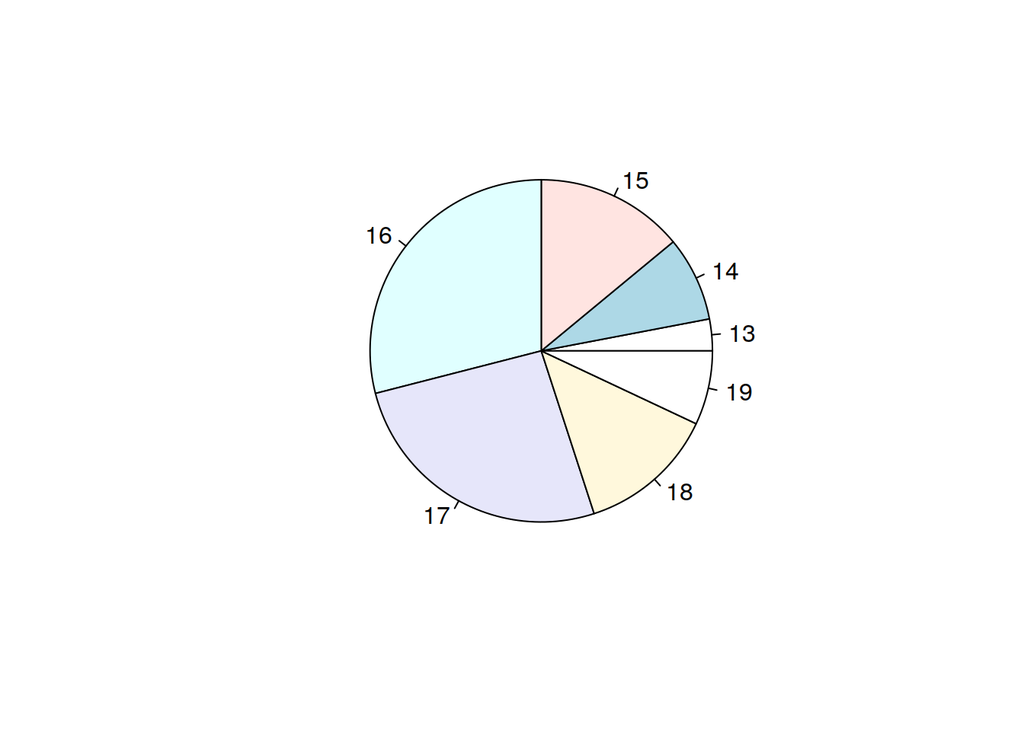

```r
pie(table(x3))
```

#### 1.1.2.2 Spojité náh. premenné

```r
set.seed(11)
x4 <- rnorm(70, mean = 20*0.8, sd = sqrt(20*0.8*0.2))  # porovnateľná s x3
```

Rozdeleníe pravdepdobnosti kvantitatívnej premennej si v textovom prevedení často zobrazujeme už spomenutou tabuľkou početností v jednotlivých skupinách (intervaloch)

```r
table(cut(x4, breaks = seq(11.5,20.5,1)))
##
## (11.5,12.5] (12.5,13.5] (13.5,14.5] (14.5,15.5] (15.5,16.5] (16.5,17.5]
##           1           5          11          14          18          11
## (17.5,18.5] (18.5,19.5] (19.5,20.5]
##           6           3           1
```

čo je v grafickej podobe histogram, vhodne doplnený kobercovým grafom. Početnosti môžu byť aj relatívne, vtedy sa dá dokresliť odhad hustoty pomocou vyhladzovacej funkcie.

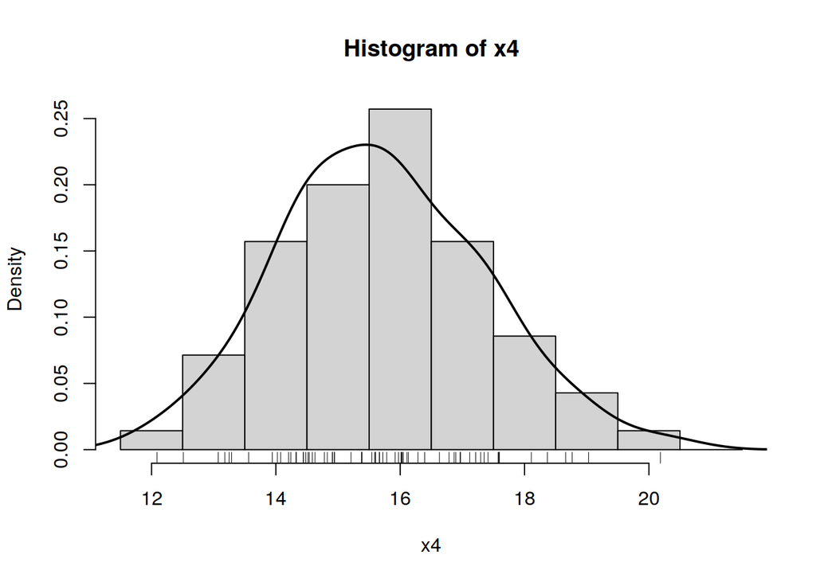

```r
hist(x4, breaks=seq(11.5,21.5,1), probability = TRUE)
rug(x4)
lines(density(x4), lwd=2)
```

Iný prístup je reprezentovať rozdelenie súhrnom tzv. (Tukeyho) 5 čísel (0,25,50,75,100% kvantily)

```r
fivenum(x4)
## [1] 12.08817 14.51805 15.63449 16.89395 20.18537
```

prípadne aj s priemerom.

```r
summary(x4)
##    Min. 1st Qu.  Median    Mean 3rd Qu.    Max.
##   12.09   14.52   15.63   15.71   16.89   20.19
```

V grafickej forme ide o **krabicový graf**, ktorý sa môže doplniť o jednorozmerný bodový graf (strip chart).

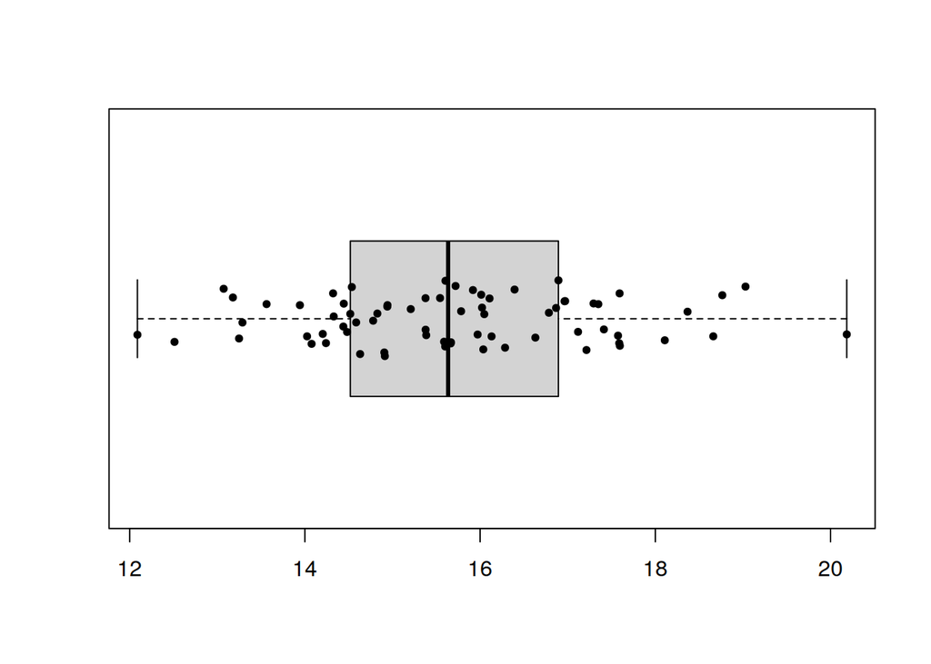

```r
boxplot(x4, horizontal = T)
stripchart(x4, add=T, method="jitter", pch=20)
```

Oba prístupy kombinuje husľový (fazuľový) graf, a tak dáva ešte lepšiu predstavu o rozdelení.

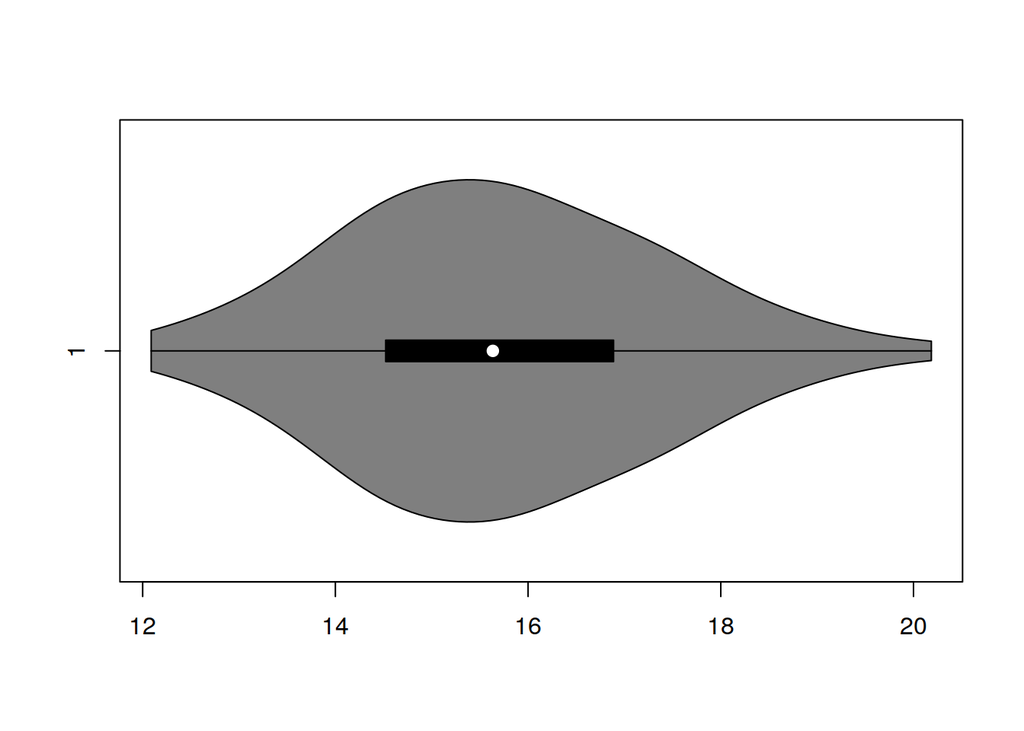

```r
vioplot::vioplot(x4, horizontal = T)
```

Na porovnanie rozdelenia náhodného výberu s konkrétnym teoretickým rozdelením sa používa kvantil-kvantilový graf (QQ plot, porovnáva empirické kvantily s teoretickými, štandardne s kvantilmi normálneho rozdelenia).

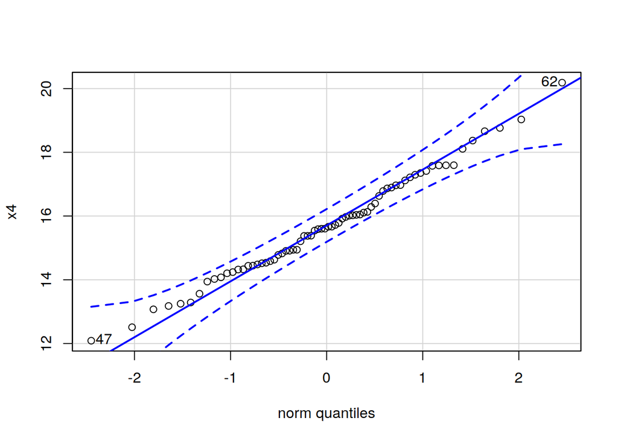

```
## [1] 62 47
```

```r
car::qqPlot(x4)
```

Pretože x4 pochádza z normálneho rozdelenia, body ležia okolo diagonálnej priamky (v páse spoľahlivosti). No pri výbere generovanom náhodne z t-rozdelenia bude vidieť odklon na koncoch (Studentovo rozdelenie má tzv. fat tails, čiže extrémne hodnoty sú pravdepodobnejšie než pri normálnom).

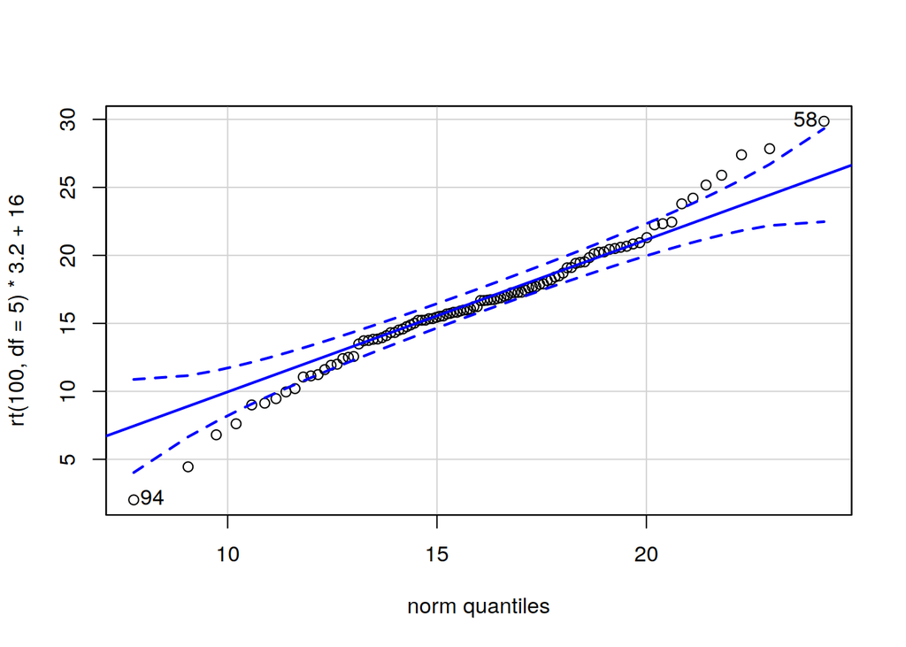

```
## [1] 94 58
```

```r
set.seed(13)
car::qqPlot(rt(100, df=5)*3.2 + 16, distribution = "norm", mean=16, sd=3.2)
```

Takmer všetky spomínané grafy sa dajú použiť aj na **porovnanie rozdelení** dvoch či viacerých náhodných výberov.

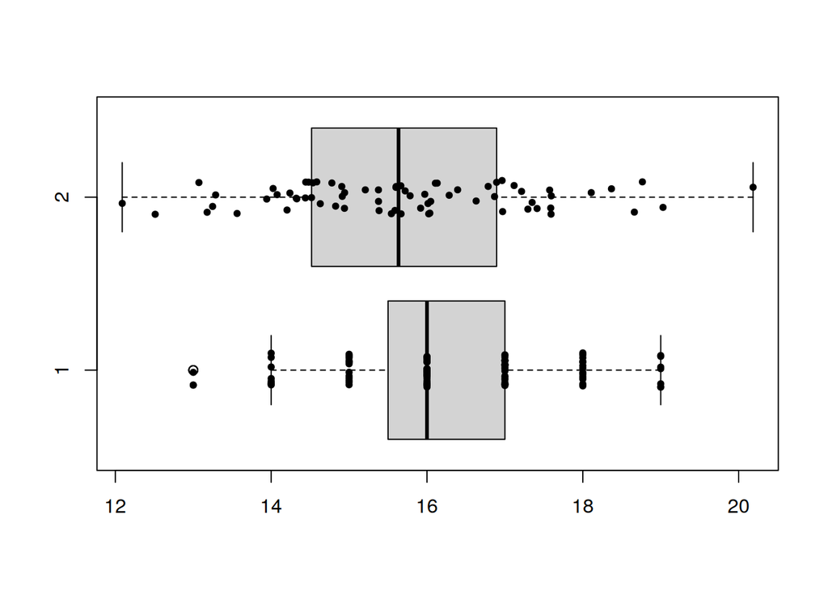

```r
boxplot(x3, x4, horizontal = T)
stripchart(list(x3,x4), add=T, method="jitter", pch=20)
```

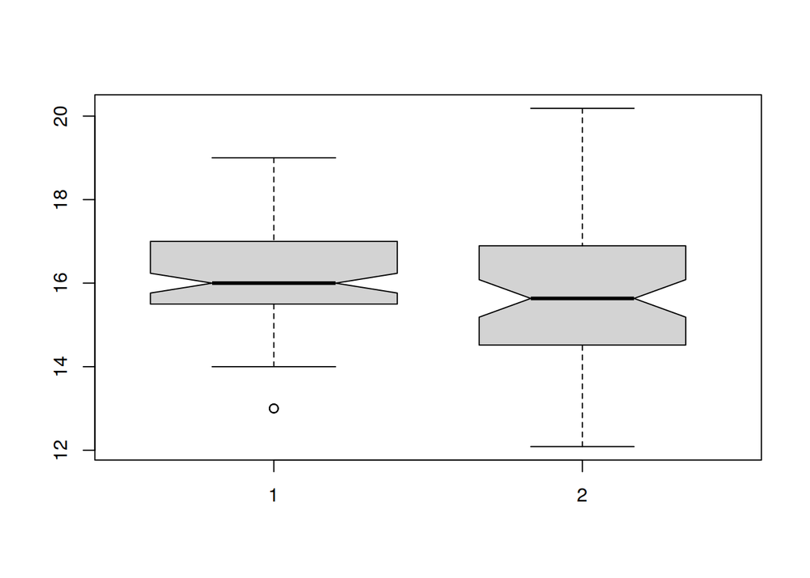

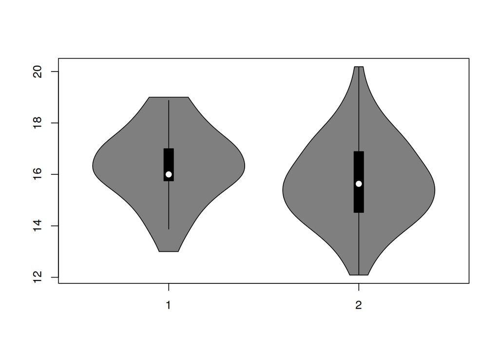

```r
boxplot(x3, x4, notch=T, varwidth = T)
vioplot::vioplot(list(x3,x4))
```

Tu sme porovnali dva nezávislé výbery x3 a x4, dokonca rôzneho typu (z diskrétnej a spojitej veličiny), no oveľa častejšie sa porovnávajú realizácie jednej kvantitatívnej premennej pozorované za rôznych podmienok (t.j. za spoluúčasti inej, kvalitatívnej premennej). Obe náhodné premenné nám tvoria systém, alebo náhodný vektor. O tom v ďalšej časti.

### 1.1.3 Prieskumná analýza systému náhodných premenných

V predošlej časti sme nahliadli do rozdelenia pravdepodobnosti jednej náhodnej premennej, na konci sme zobrazili dve podobné náhodné premenné vedľa seba v krabicovom grafe. V praxi je však často výsledkom experimentu množstvo premenných (štatistických znakov, vlastností nejakého objektu), ktoré spolu môžu súvisieť a tak izolovaným vyšetrovaním rozdelenia by sme prichádzali o dôležité informácie. Namiesto toho je vhodné vyšetriť rozdelenie pravdepodobnosti jednej premennej podmienené hodnotou inej/iných premenných (tzv. podmienené rozdelenie pravdepodobnosti).

```r
data(mtcars)
```

#### 1.1.3.1 Dve spojité (kvantitatívne)

Najčastejší nástroj pre zobrazenie vzťahu **dvoch spojitých** náhodných premenných je XY graf (scatter plot).

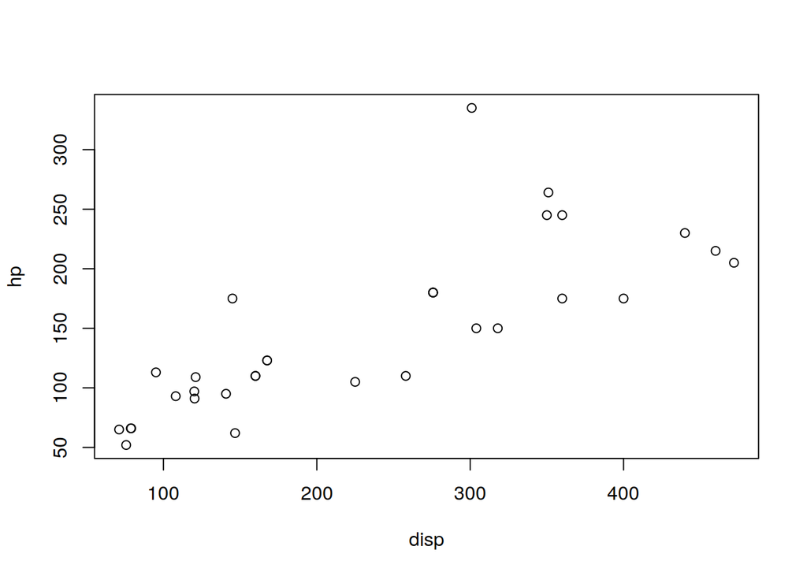

```r
plot(hp ~ disp, data=mtcars)
```

Z grafu vidno, že výkon motora značne súvisí so zdvihovým objemom. Jedno z áut je výrazne efektívne vo využití objemu valcov, že by to súviselo s počtom valcov? Pozrime, o ktoré auto ide.

```r
mtcars[which.max(mtcars$hp),]
##               mpg cyl disp  hp drat   wt qsec vs am gear carb
## Maserati Bora  15   8  301 335 3.54 3.57 14.6  0  1    5    8
```

Zjavne ide o 8-valec, pozrime teda ešte na ostatné 8-valcové modely a pre lepší prehľad zoraďme podľa výkonu.

```r
tmp <- subset(mtcars, subset = cyl == "8")
tmp[order(tmp$hp, decreasing=T),]
##                      mpg cyl  disp  hp drat    wt  qsec vs am gear carb
## Maserati Bora       15.0   8 301.0 335 3.54 3.570 14.60  0  1    5    8
## Ford Pantera L      15.8   8 351.0 264 4.22 3.170 14.50  0  1    5    4
## Duster 360          14.3   8 360.0 245 3.21 3.570 15.84  0  0    3    4
## Camaro Z28          13.3   8 350.0 245 3.73 3.840 15.41  0  0    3    4
## Chrysler Imperial   14.7   8 440.0 230 3.23 5.345 17.42  0  0    3    4
## Lincoln Continental 10.4   8 460.0 215 3.00 5.424 17.82  0  0    3    4
## Cadillac Fleetwood  10.4   8 472.0 205 2.93 5.250 17.98  0  0    3    4
## Merc 450SE          16.4   8 275.8 180 3.07 4.070 17.40  0  0    3    3
## Merc 450SL          17.3   8 275.8 180 3.07 3.730 17.60  0  0    3    3
## Merc 450SLC         15.2   8 275.8 180 3.07 3.780 18.00  0  0    3    3
## Hornet Sportabout   18.7   8 360.0 175 3.15 3.440 17.02  0  0    3    2
## Pontiac Firebird    19.2   8 400.0 175 3.08 3.845 17.05  0  0    3    2
## Dodge Challenger    15.5   8 318.0 150 2.76 3.520 16.87  0  0    3    2
## AMC Javelin         15.2   8 304.0 150 3.15 3.435 17.30  0  0    3    2
```

S polu s druhým najvýkonnejším má manuálnu prevodovku, 5 rýchlostných stupňov a pomerne nízku hmotnosť. Zobraziť vzťah viac než dvoch premenných priamym pridávaním rozmerov (3D, video?) by bolo neefektívneje, existujú aj lacnejšie triky, napr. pomocou farby, veľkosti a tvaru bodov.

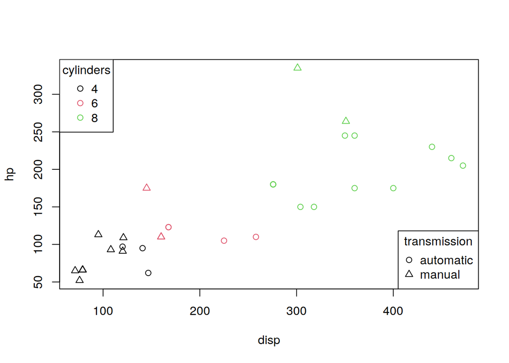

```r
plot(hp ~ disp, data=mtcars,
     col = as.integer(as.factor(mtcars$cyl)),
     pch = mtcars$am+1
)
legend("topleft", legend = c(4,6,8), pch=1, col=1:3, title="cylinders")
legend("bottomright", legend = c("automatic","manual"), pch=1:2, title="transmission")
```

Podobne možno použiť tzv. bublinový graf (bubble plot) na vyjadrenie závislosti napr. medzi výkonom motora a dojazdom v závislosti od počtu valcov a ešte aj doplniť popis

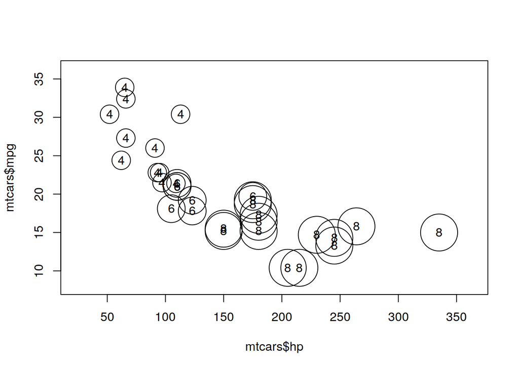

```r
symbols(x = mtcars$hp, y = mtcars$mpg,
        circles=mtcars$cyl,
        inches = 0.25)
text(x = mtcars$hp, y = mtcars$mpg,
     mtcars$cyl)
```

Tento graf je vhodný v prípadoch, kedy podmieňujúca premenná (cylinders) je ordinálna a body nie sú príliš nahusto (čo asi nie je tento prípad.

#### 1.1.3.2 Diskrétna (kvalitatívna) a spojitá

Závislosť **diskrétnej a spojitej** premennej sa štandardne zobrazuje krabicovými grafmi u ktorých šírka môže reflektovať napr. počet pozorovaní:

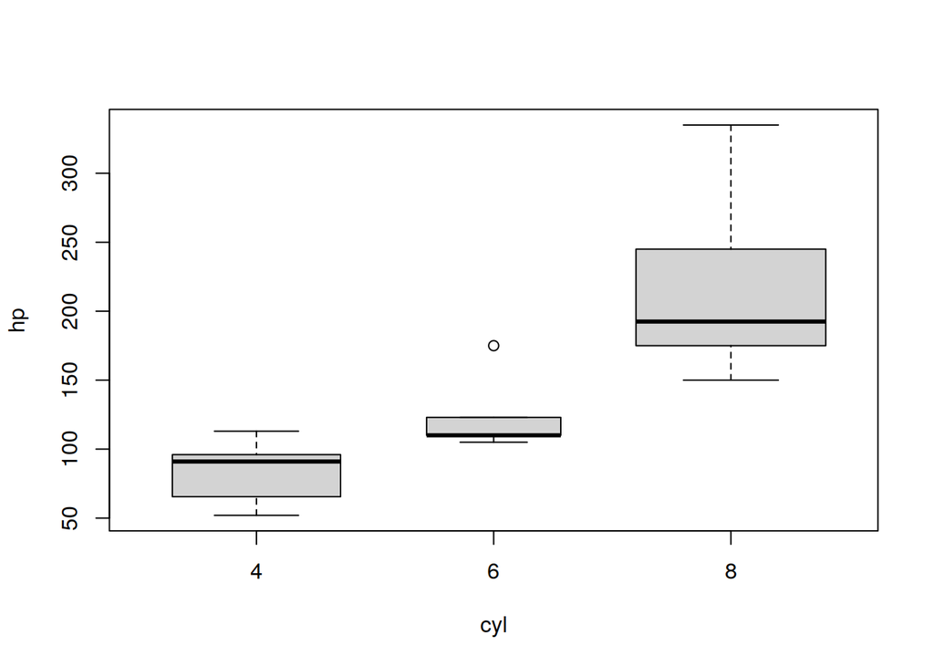

```r
aggregate(hp ~ cyl, mtcars, FUN = summary)
##   cyl   hp.Min. hp.1st Qu. hp.Median   hp.Mean hp.3rd Qu.   hp.Max.
## 1   4  52.00000   65.50000  91.00000  82.63636   96.00000 113.00000
## 2   6 105.00000  110.00000 110.00000 122.28571  123.00000 175.00000
## 3   8 150.00000  176.25000 192.50000 209.21429  241.25000 335.00000
# sapply(split(mtcars$hp, mtcars$cyl), summary)
# tapply(mtcars$hp, INDEX = mtcars$cyl, FUN = summary) %>% simplify2array()
boxplot(hp ~ cyl, data=mtcars, varwidth=T)  # s faktormi aj pomocou plot()
```

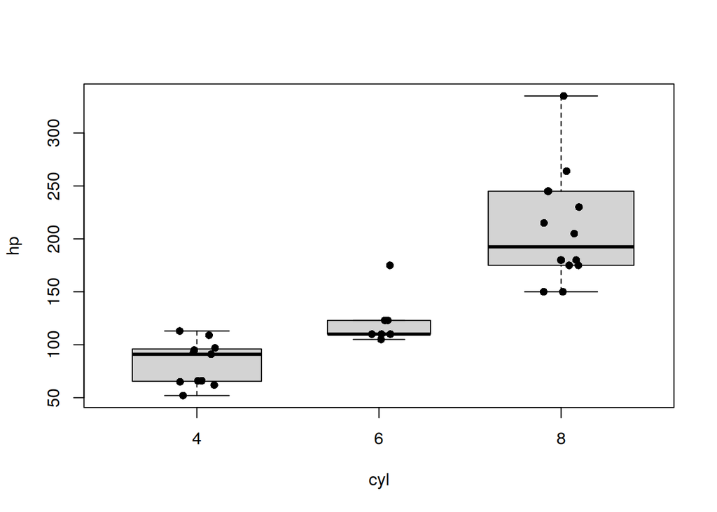

```r
boxplot(hp ~ cyl, data=mtcars, varwidth=T, cex=0)
stripchart(hp ~ cyl, data=mtcars, add=T, vertical=TRUE, method="jitter", pch=16)
```

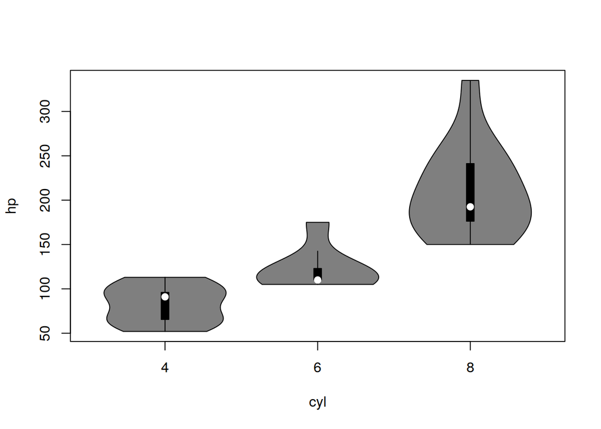

```r
vioplot::vioplot(hp ~ cyl, data=mtcars)
```

Nárast výkonu u 6 valcových motorov nie je tak zásadný ako u 8 valcových.

#### 1.1.3.3 Dve diskrétne

**Dve diskrétne** premenné možno zobraziť mozaikovým grafom, ktorý v plošnej miere vyjadruje početnosti v prienikoch jednotlivých kategórií.

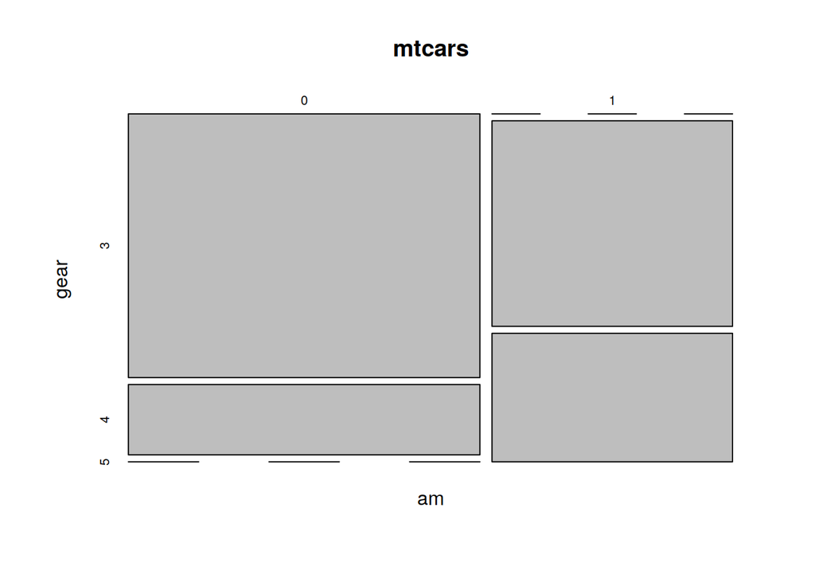

```r
with(mtcars, table(am, gear))
##    gear
## am   3  4  5
##   0 15  4  0
##   1  0  8  5
mosaicplot(am ~ gear, data=mtcars)
```

Z toho vidno nielen vyššiu celkovú početnosť automobilov s automatickou prevodovkou ale hlavne negatívnu závislosť oboch veličín (automaty ešte nezvládali veľa prevodov).

#### 1.1.3.4 Viac numerických

**Viac numerických** premenných - každá s každou, s farebným rozlíšením podľa jednej diskrétnej premennej.

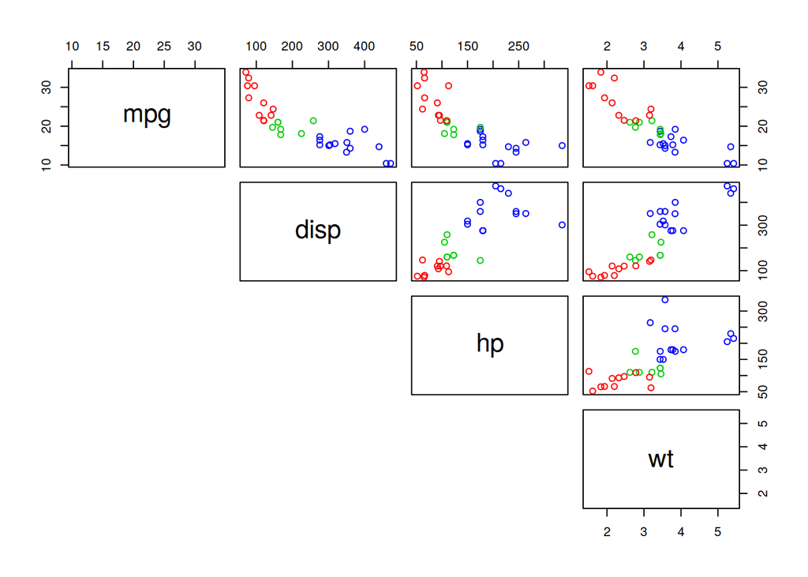

```r
pairs(~ mpg + disp + hp + wt, data = mtcars,
      col = c("red","green3","blue")[as.factor(mtcars$cyl)],
      lower.panel = NULL
)
```

Skupina panelov (v hornom/dolnom trojuholníku a na diagonále) sa dá definovať samostatne, no ľahšie je použiť už pripravené funkcie, napr.

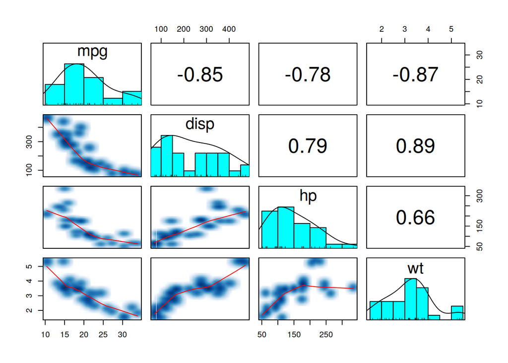

```r
psych::pairs.panels(mtcars[c("mpg", "disp", "hp", "wt")],
                    ellipses = F, smooth = T, smoother = T,  # niektore prepinace pre dolny trojuholnik
                    density = T, rug = T,   # diagonalu
                    cor = T, cex.cor = 0.8,  # horny trojuholnik
)
```

Rozostrenie (smoother) je výhodné pri zobrazení väčšieho množstva údajov, keď by už značky jednotlivých bodov splývali. Vyhladzujúca krivka (smooth) zjednodušuje vývoj závislosti medzi oboma premennými. Číslo v hornom trojuholníku je korelačný koeficient vyjadrujúci na intervale (-1,1) silu závislosti so špeciálnymi prípadmi: -1 nepriama úmernosť, 0 nekorelovanosť, +1 priama úmernosť. To znamená, že čím ďalej je hodnota korelácie ďalej od 0, tým väčšmi závisí rozdelenie náhodnej premennej od hodnôt inej premennej.

Pozn. Každý z predstavených grafov je možné pomocou argumentu *subset* jednoducho aplikovať aj na podmnožinu pozorovaní, napr.

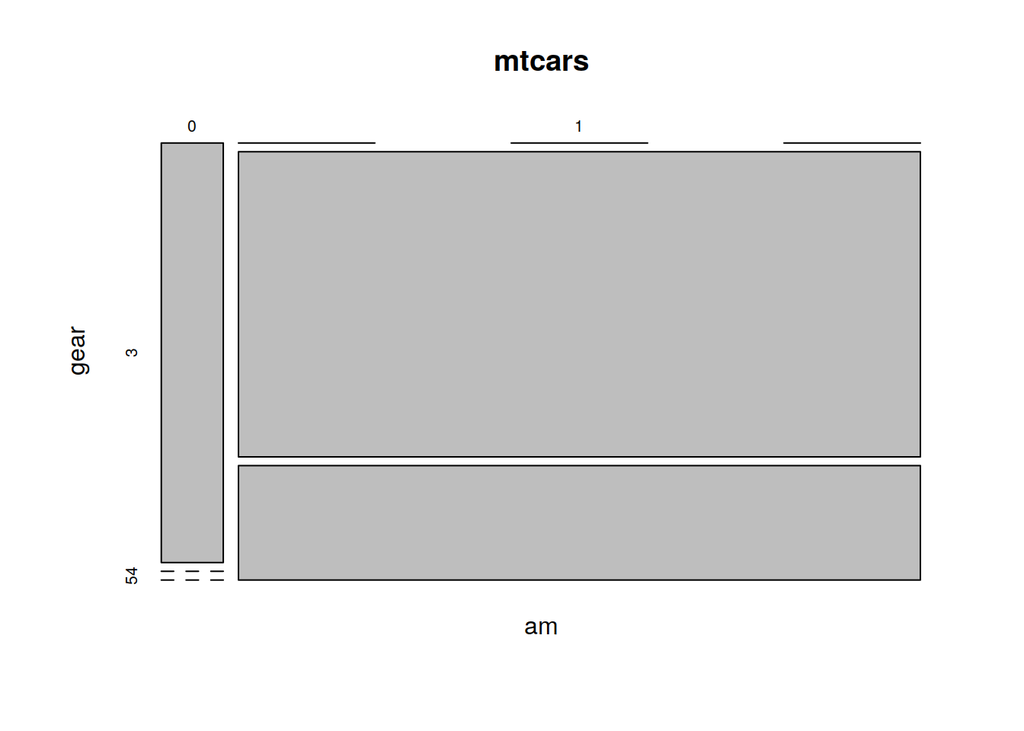

```r
mosaicplot(am ~ gear, data=mtcars, subset = wt<3.0)
```

z ktorého je zjavná prevaha 4-rýchlostných manuálnych prevodoviek v triede ľahších automobilov. Pridanie ďalších diskrétnych premenných uľahčí napr. balík *vcd* (Visualizing Categorical Data).